# Personal Notes

# Setting Up

```r
library(xgboost)
library(caret)
```

```r
library(Matrix)
library(ggplot2)
```

# Exploratory analysis

Read data and combine train and test into one dataframe.

```r
dat_train <- read.csv("train.csv", stringsAsFactors = FALSE)
dat_test <- read.csv("test.csv", stringsAsFactors = FALSE)

dat_test$TARGET <- -1
all_dat <- rbind(dat_train, dat_test)
```

Examine the imbalance of classes.

```r
table(dat_train$TARGET)
```

```
##
##     0     1
## 73012  3008
```

```r
prop.table(table(dat_train$TARGET))
```

```
##
##          0          1
## 0.96043147 0.03956853
```

Detect missing values.

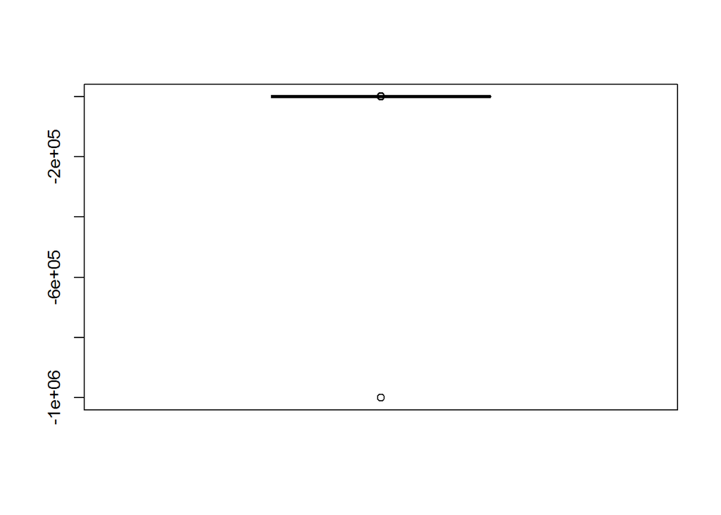

```r
boxplot(all_dat$var3)
```

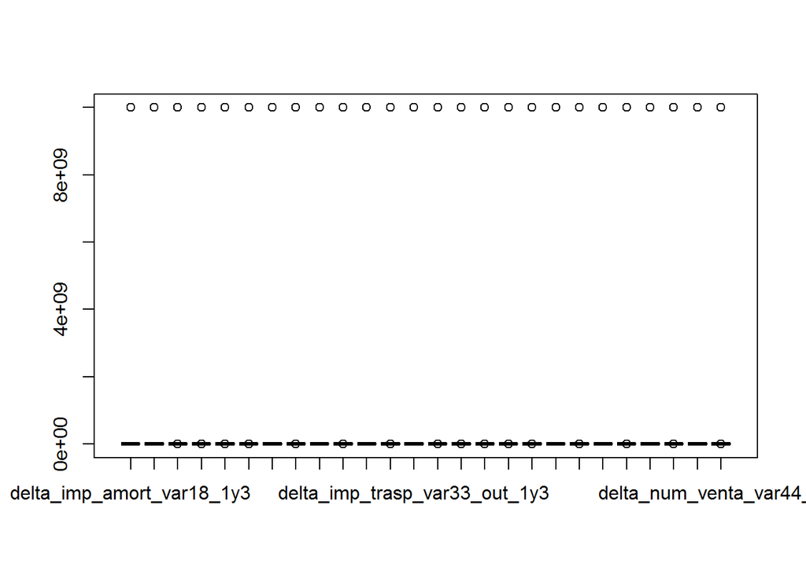

```r
boxplot(all_dat[,grep('delta', names(all_dat))])
```

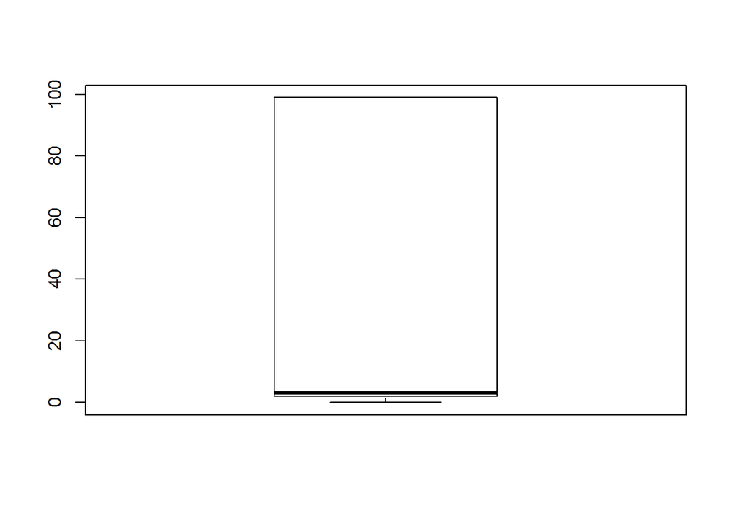

```r
boxplot(all_dat$var36)
```

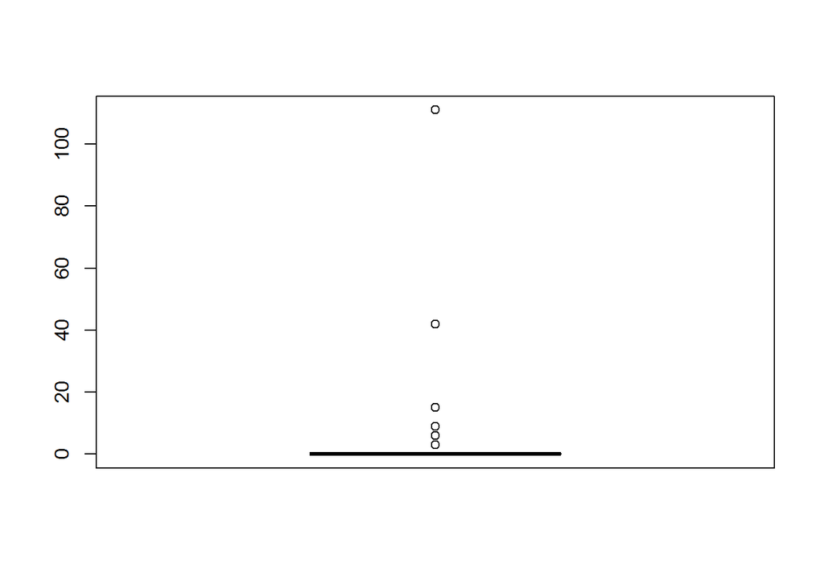

```r
boxplot(all_dat$num_var12_0)
```

Multi-class variables

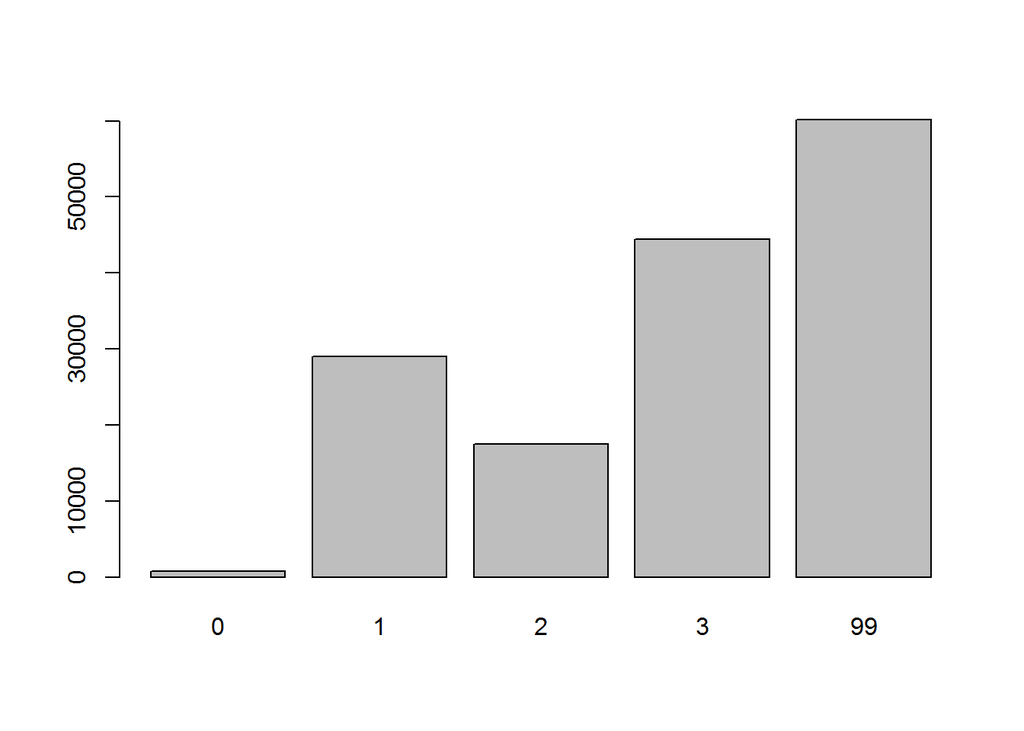

```r
barplot(table(all_dat$var36))
```

Binary variables

```r
summary(mapply(as.factor, all_dat[, grep('^ind', names(all_dat))]))
```

```
##  ind_var1_0 ind_var1   ind_var2_0 ind_var2   ind_var5_0 ind_var5
##  0:150049   0:151255   0:151838   0:151838   0:  6451   0: 51055
##  1:  1789   1:   583                         1:145387   1:100783
##  ind_var6_0 ind_var6   ind_var8_0 ind_var8   ind_var12_0 ind_var12
##  0:151823   0:151834   0:146788   0:147398   0:141503    0:144943
##  1:    15   1:     4   1:  5050   1:  4440   1: 10335    1:  6895
##  ind_var13_0 ind_var13_corto_0 ind_var13_corto ind_var13_largo_0
##  0:143832    0:145277          0:145489        0:150249
##  1:  8006    1:  6561          1:  6349        1:  1589
##  ind_var13_largo ind_var13_medio_0 ind_var13_medio ind_var13  ind_var14_0
##  0:150276        0:151831          0:151831        0:144039   0:148189
##  1:  1562        1:     7          1:     7        1:  7799   1:  3649
##  ind_var14  ind_var17_0 ind_var17  ind_var18_0 ind_var18  ind_var19
##  0:151045   0:151579    0:151622   0:151835    0:151835   0:151235
##  1:   793   1:   259    1:   216   1:     3    1:     3   1:   603
##  ind_var20_0 ind_var20  ind_var24_0 ind_var24  ind_var25_cte ind_var26_0
##  0:151303    0:151448   0:145363    0:146073   0:147708      0:148002
##  1:   535    1:   390   1:  6475    1:  5765   1:  4130      1:  3836
##  ind_var26_cte ind_var26  ind_var25_0 ind_var25  ind_var27_0 ind_var28_0
##  0:147523      0:148002   0:148163    0:148163   0:151838    0:151838
##  1:  4315      1:  3836   1:  3675    1:  3675
##  ind_var28  ind_var27  ind_var29_0 ind_var29  ind_var30_0 ind_var30
##  0:151838   0:151838   0:151823    0:151834   0:   699    0: 40480
##                        1:    15    1:     4   1:151139    1:111358
##  ind_var31_0 ind_var31  ind_var32_cte ind_var32_0 ind_var32  ind_var33_0
##  0:151184    0:151267   0:151637      0:151662    0:151662   0:151715
##  1:   654    1:   571   1:   201      1:   176    1:   176   1:   123
##  ind_var33  ind_var34_0 ind_var34  ind_var37_cte ind_var37_0 ind_var37
##  0:151732   0:151834    0:151834   0:140980      0:142004    0:142004
##  1:   106   1:     4    1:     4   1: 10858      1:  9834    1:  9834
##  ind_var39_0 ind_var40_0 ind_var40  ind_var41_0 ind_var41  ind_var39
##  0: 17970    0:150054    0:151260   0: 18205    0:151838   0:151260
##  1:133868    1:  1784    1:   578   1:133633               1:   578
##  ind_var44_0 ind_var44  ind_var46_0 ind_var46  ind_var7_emit_ult1
##  0:151542    0:151570   0:151838    0:151838   0:151833
##  1:   296    1:   268                          1:     5
##  ind_var7_recib_ult1 ind_var10_ult1 ind_var10cte_ult1 ind_var9_cte_ult1
##  0:151445            0:139530       0:137871          0:137123
##  1:   393            1: 12308       1: 13967          1: 14715
##  ind_var9_ult1 ind_var43_emit_ult1 ind_var43_recib_ult1
##  0:138745      0:141620            0:132330
##  1: 13093      1: 10218            1: 19508
```

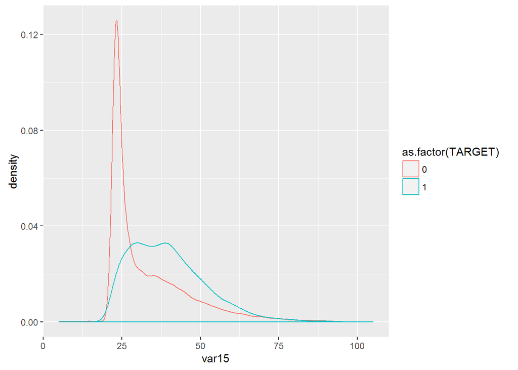

```r
qplot(var15, data=dat_train, colour=as.factor(TARGET), geom='density')
```

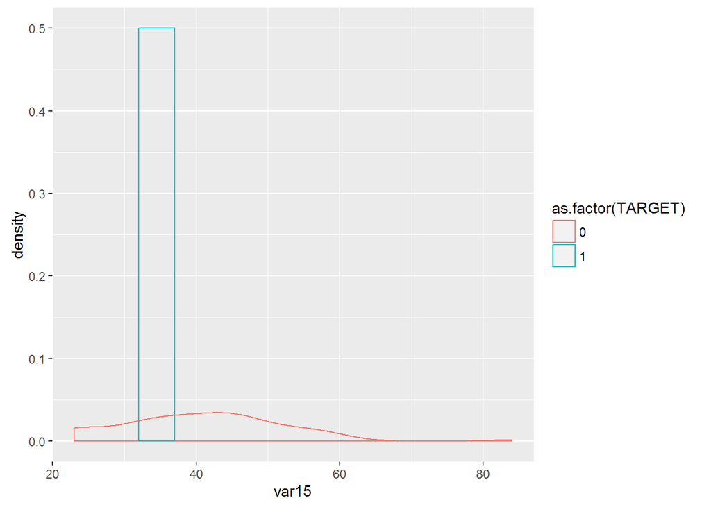

```r
qplot(var15, data=dat_train[dat_train$var3 == 6, ], geom='density', col=as.factor(TARGET))
```

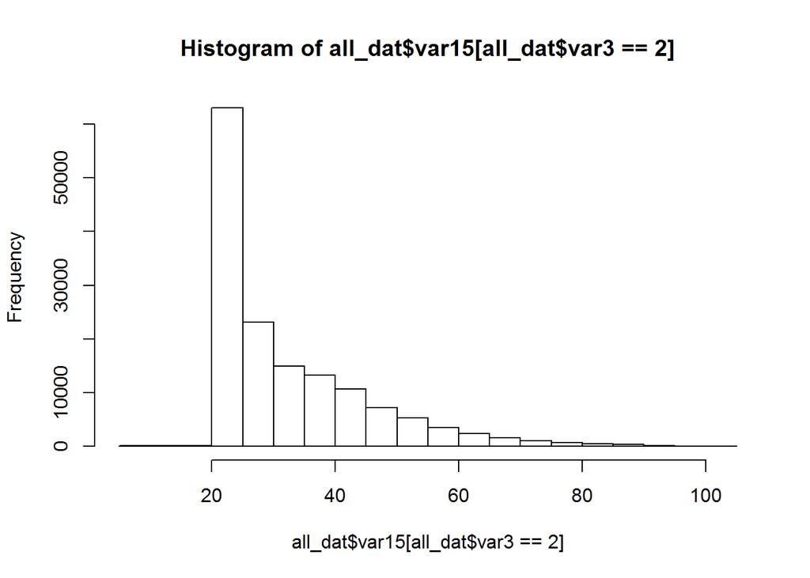

```r
hist(all_dat$var15[all_dat$var3 == 2])
```

```r
table(dat_train$TARGET[dat_train$var15 > 30])
```

```
##
##     0     1
## 30290  2228
```

saldo_var_30 is also very important. ind seems to be an indicator of something about the customer.

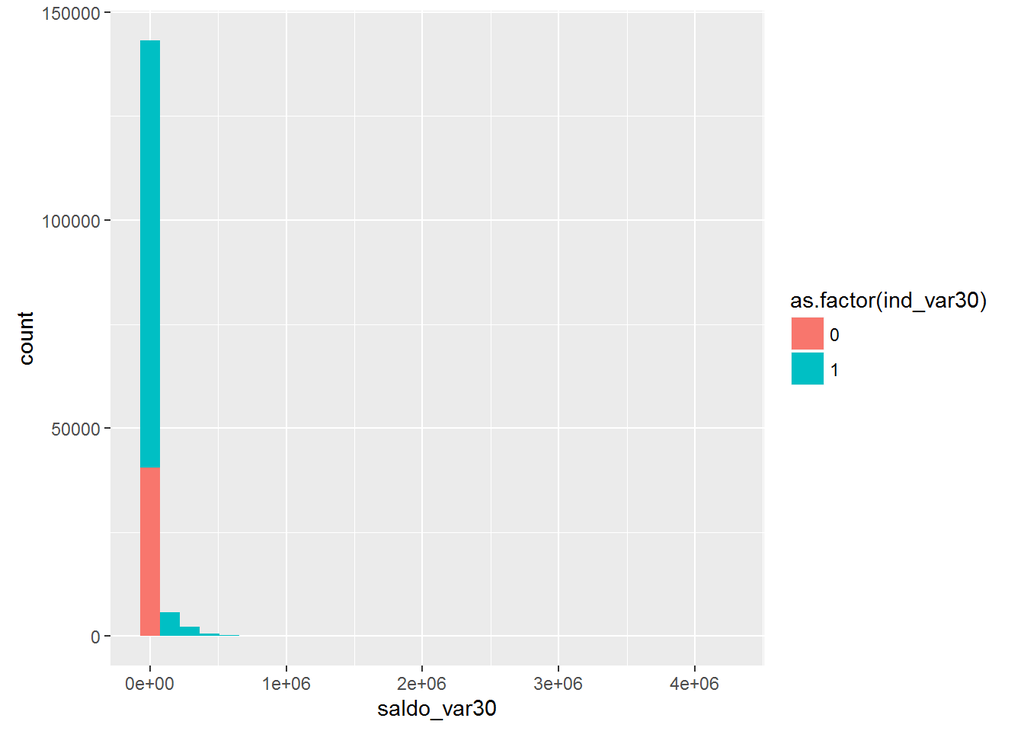

```r
qplot(saldo_var30, data=all_dat, fill=as.factor(ind_var30), geom='histogram')
```

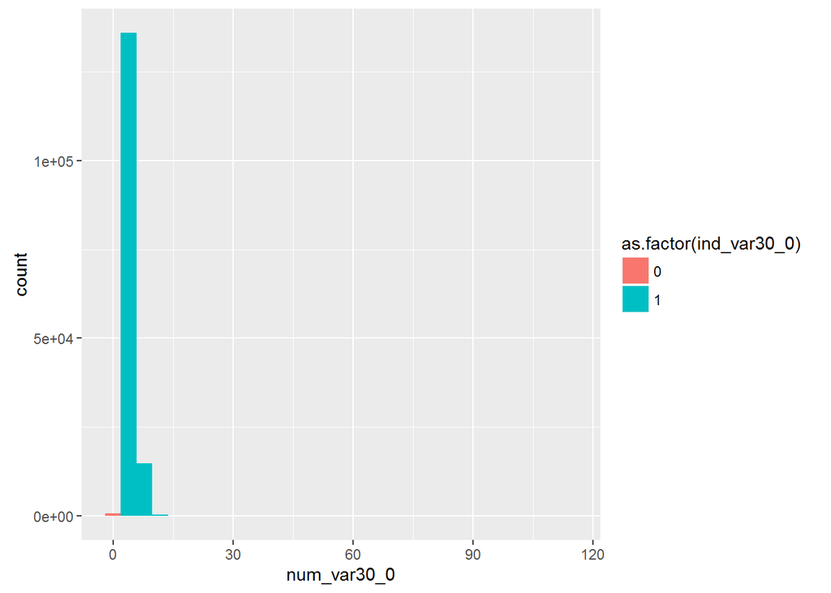

```r
qplot(num_var30_0, data=all_dat, fill=as.factor(ind_var30_0), geom='histogram')
```

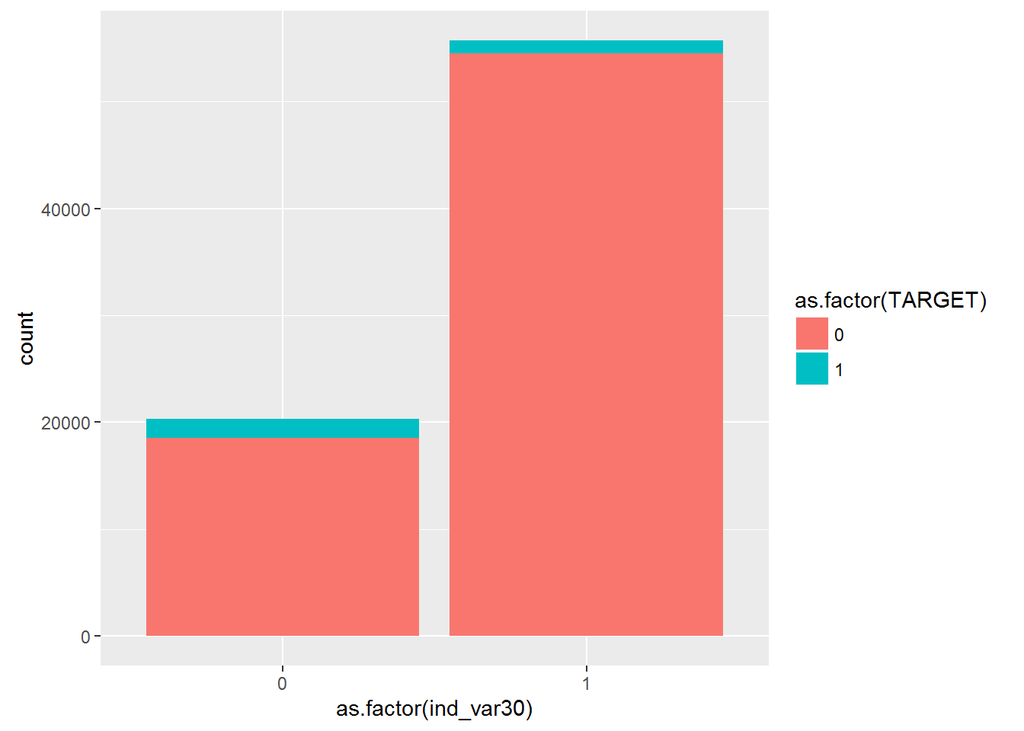

```r
qplot(as.factor(ind_var30), data=dat_train, fill=as.factor(TARGET))
```

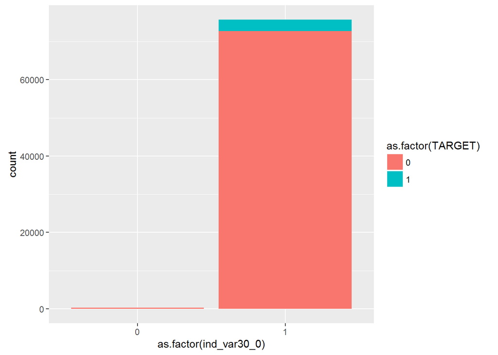

```r
qplot(as.factor(ind_var30_0), data=dat_train, fill=as.factor(TARGET))
```

```r
cor(dat_train$ind_var30, dat_train$TARGET)
```

```
## [1] -0.1498105
```

customers with negative balance have 20% proportion of being unhappy! but this is negligible compared to the entire dataset.

```r
table(dat_train$TARGET[dat_train$saldo_var30 < 0]) #type1: NegSaldo
```

```
##
##  0  1
## 99 21
```

```r
table(dat_train$TARGET[dat_train$saldo_var5 < 0]) #type 1
```

```
##
##  0  1
## 90 18
```

```r
table(dat_train$TARGET[dat_train$saldo_var8 < 0]) #type 1
```

```
##
##  0  1
## 15  4
```

# Data cleaning

First, one piece of feature engineering.

```r
# count no. of nonzero elements
all_dat$nonzero <- apply(all_dat, 1, function(x) (sum(x == 0)))
```

## Removing constant variables

First is to encode missing values with NA.

```r
all_dat[all_dat$var3 == -999999, "var3"] <- NA
delta_vars <- names(all_dat)[grep('^delta', names(all_dat))]
for(i in delta_vars){
  all_dat[all_dat[, i] == 9999999999, i] <- NA
}
all_dat[all_dat$var36 == 99, "var36"] <- NA
all_dat[all_dat$num_var12_0 == 111, "num_var12_0"] <- NA
```

Next is to remove variables with zero variance.

```r
zeroVar <- nearZeroVar(all_dat, saveMetrics = TRUE, freqCut = (nrow(all_dat) - 10)/10,uniqueCut = 1000/nrow(all_dat))
names(all_dat)[zeroVar[,"nzv"]]
```

```
##  [1] "ind_var2_0"                    "ind_var2"
##  [3] "ind_var6"                      "ind_var13_medio_0"
##  [5] "ind_var13_medio"               "ind_var18_0"
##  [7] "ind_var18"                     "ind_var27_0"
##  [9] "ind_var28_0"                   "ind_var28"
## [11] "ind_var27"                     "ind_var29"
## [13] "ind_var34_0"                   "ind_var34"
## [15] "ind_var41"                     "ind_var46_0"
## [17] "ind_var46"                     "num_var6"
## [19] "num_var13_medio_0"             "num_var13_medio"
## [21] "num_var18_0"                   "num_var18"
## [23] "num_op_var40_hace3"            "num_var27_0"
## [25] "num_var28_0"                   "num_var28"
## [27] "num_var27"                     "num_var29"
## [29] "num_var34_0"                   "num_var34"
```

[output cut: 34 more lines]

```r
all_dat <- all_dat[, !zeroVar[, "nzv"]]
```

## Removing identical variables

```r
temp <- names(all_dat)[duplicated(lapply(all_dat, summary))]
cat(temp, sep="\n")
```

```
## ind_var26
## ind_var25
## ind_var29_0
## ind_var32
## ind_var37
## ind_var39
## num_var26
## num_var25
## num_var29_0
## num_var32
## num_var37
## num_var39
## delta_num_trasp_var33_in_1y3
```

```r
all_dat <- all_dat[!duplicated(lapply(all_dat, summary))]
cat("Deleted ", length(temp), " duplicated variables.")
```

```
## Deleted  13  duplicated variables.
```

# Feature engineering

```r
# convert to categorical
all_dat$var36 <- as.factor(all_dat$var36)

# balance/saldo small
all_dat$saldo0 <- apply(all_dat[, grep('^saldo', names(all_dat))], 1, function(x)(sum(x < 0)))
all_dat$spain30 <- (all_dat$var15 > 30 & all_dat$var3 == 2) * 1

# ratios
all_dat$var5_ratio <- (all_dat$saldo_medio_var5_hace2 + 1)/(all_dat$saldo_medio_var5_hace3 + 1)
```

# Modeling

xgboost preprocessing

```r
# one-hot encoding
dummies <- dummyVars(~var36, data=all_dat)
ohe <- as.data.frame(predict(dummies, newdata=all_dat))
all_dat <- cbind(all_dat[, ! names(all_dat) %in% c('var36')], ohe)

# standardize NA to -9999 (required for dmatrix)
all_dat[is.na(all_dat$var3), "var3"] <- -9999
delta_vars <- names(all_dat)[grep('^delta', names(all_dat))]
for(i in delta_vars){
  all_dat[is.na(all_dat[, i]), i] <- -9999
}
var36s <- names(all_dat)[grep('var36', names(all_dat))]
for(i in var36s){
  all_dat[is.na(all_dat[, i]), i] <- -9999
}
all_dat[is.na(all_dat$num_var12_0), "num_var12_0"] <- -9999
all_dat[is.na(all_dat$spain30), "spain30"] <- -9999

names(all_dat)
```

```
##   [1] "ID"                            "var3"
##   [3] "var15"                         "imp_ent_var16_ult1"
##   [5] "imp_op_var39_comer_ult1"       "imp_op_var39_comer_ult3"
##   [7] "imp_op_var40_comer_ult1"       "imp_op_var40_comer_ult3"
##   [9] "imp_op_var40_efect_ult1"       "imp_op_var40_efect_ult3"
##  [11] "imp_op_var40_ult1"             "imp_op_var41_comer_ult1"
##  [13] "imp_op_var41_comer_ult3"       "imp_op_var41_efect_ult1"
##  [15] "imp_op_var41_efect_ult3"       "imp_op_var41_ult1"
##  [17] "imp_op_var39_efect_ult1"       "imp_op_var39_efect_ult3"
##  [19] "imp_op_var39_ult1"             "imp_sal_var16_ult1"
##  [21] "ind_var1_0"                    "ind_var1"
##  [23] "ind_var5_0"                    "ind_var5"
##  [25] "ind_var6_0"                    "ind_var8_0"
##  [27] "ind_var8"                      "ind_var12_0"
##  [29] "ind_var12"                     "ind_var13_0"
```

[output cut: 119 more lines]

```r
train <- all_dat[all_dat$ID %in% dat_train$ID, ]
test <- all_dat[all_dat$ID %in% dat_test$ID, ]

y.train <- train$TARGET
train$ID <- NULL
train <- sparse.model.matrix(TARGET ~ .-1, data=train)
dtrain <- xgb.DMatrix(data=train, label=y.train, missing=-9999)

ID.test <- test$ID
test$ID <- NULL
test <- sparse.model.matrix(TARGET ~. -1, data=test)
```

xgboost algorithm

```r
param <- list(objective = "binary:logistic",
              booster = "gbtree",
              eval_metric = "auc",
              nthread=2,
                    eta=0.02,
                    max_depth=4,
                    colsample_bytree=0.5,
                    subsample=1,
                    min_child_weight=10,
                    max_delta_step=5)

clf <- xgb.train(       params              = param,
                        data = dtrain,
                        nrounds             = 900,
                        verbose             = 0
       )
```

How many we get it right?

```r
prop.table(table(dat_train$TARGET))
```

```
##
##          0          1
## 0.96043147 0.03956853
```

```r
confusionMatrix(ifelse(predict(clf, newdata=train, missing=-9999) > 0.5, 1, 0), dat_train$TARGET)
```

```
## Confusion Matrix and Statistics
##
##           Reference
## Prediction     0     1
##          0 72949  1295
##          1    63  1713
##
##                Accuracy : 0.9821
##                  95% CI : (0.9812, 0.9831)
##     No Information Rate : 0.9604
##     P-Value [Acc > NIR] : < 2.2e-16
##
##                   Kappa : 0.7075
##  Mcnemar's Test P-Value : < 2.2e-16
##
##             Sensitivity : 0.9991
##             Specificity : 0.5695
##          Pos Pred Value : 0.9826
##          Neg Pred Value : 0.9645
##              Prevalence : 0.9604
##          Detection Rate : 0.9596
##    Detection Prevalence : 0.9766
##       Balanced Accuracy : 0.7843
##
##        'Positive' Class : 0
##
```

# Feature importance

Variable importance as obtained from xgboost.

```r
importance_matrix <- xgb.importance(train@Dimnames[[2]],model= clf)

importance_matrix
```

```
##                       Feature         Gain        Cover    Frequence
##   1:                  nonzero 5.874643e-01 2.684343e-01 0.2614236867
##   2:                    var15 6.576002e-02 1.252176e-01 0.0552274376
##   3:              saldo_var30 5.941419e-02 9.533903e-02 0.0450730494
##   4: num_meses_var39_vig_ult3 2.890687e-02 8.177042e-03 0.0298414672
##   5:                  spain30 2.538295e-02 3.132012e-02 0.0116050150
##  ---
## 106:    num_aport_var13_hace3 1.816377e-05 2.613595e-04 0.0002072324
## 107:      num_meses_var8_ult3 1.295431e-05 1.557084e-05 0.0001036162
## 108:           ind_var10_ult1 8.081179e-06 8.452265e-06 0.0001036162
## 109:              saldo_var24 3.023374e-06 5.895515e-06 0.0001036162
## 110:        saldo_var13_corto 1.325752e-06 1.802479e-06 0.0001036162
```

```r
#xgb.plot.importance(importance_matrix[1:20, ])
```

# Other notes

- AGE = var15
- number of months = ‘^num_meses’
- var3 = country of residence.

Few things to try * Impute from Hmisc * var17 financing product? * k-NN /clustering * ensemble learning * vowpaw wabbit

Treating age variable as discrete/age ranges doesn’t improve the AUC. Code is below.

```r
# all_dat$ageDiscrete <- NA
# all_dat[all_dat$age < 18, "ageDiscrete" ] <- "below.18"
# all_dat[all_dat$age >= 18 &  all_dat$age < 28, "ageDiscrete"] <- "18.to.25"
# all_dat[all_dat$age >= 28 & all_dat$age < 40, "ageDiscrete" ] <- "28.to.40"
# all_dat[all_dat$age >= 40 & all_dat$age < 70, "ageDiscrete"] <- "40.to.70"
# all_dat[all_dat$age >= 70, "ageDiscrete"] <- "70.above"
# all_dat$ageDiscrete <- as.factor(all_dat$ageDiscrete)
```

Removing correlated variables prevents overfitting somehow, but perhaps it’s because this is removing very sparse variables.

```r
# cor_v <- abs(cor(all_dat))
# diag(cor_v) <- 0
# cor_v[upper.tri(cor_v)] <- 0
# cor_v <- as.data.frame(which(cor_v > 0.85, arr.ind = T))
# names(all_dat)[unique(cor_v$row)]
# all_dat <- all_dat[,-unique(cor_v$row)]
# cat("Deleted ", length(unique(cor_v$row)), " correlated variables.")
```